# **Laboratorio 1 - Series de Tiempo**

- Derek Arreaga - 22537
- Mónica Salvatierra - 22249

*Todo el código fuente se encuentra dentro del repositorio de GitHub, incluyendo los análisis individuales de cada dataset.*

Link del repositorio: https://github.com/alee2602/LAB1-DS

### **Introducción**

En este análisis se aplicaron y compararon distintos modelos de predicción de series temporales sobre cuatro datasets reales. El objetivo principal fue evaluar el desempeño de modelos clásicos y modernos, como Holt-Winters, SARIMA y Prophet, para seleccionar el que mejor predice las variables objetivo según el caso. La evaluación se basó en métricas de error como RMSE y MAE.

### **Descripción de los datasets**

- **`daily-total-female-births.csv`**: Nacimientos diarios de mujeres en California durante 1959. La distribución es **ligeramente sesgada a la derecha**, con la mayoría de los valores entre 35 y 50. Se observan algunos picos inusuales, pero **no hay estacionalidad clara ni tendencia marcada**.
- **`shampoo.csv`**: Ventas mensuales de shampoo entre 2001 y 2003. La serie es **altamente variable y no simétrica**, con algunos picos abruptos. Muestra una **tendencia creciente** y posible **estacionalidad irregular**, influida por factores comerciales.
- **`monthly-mean-temp.csv`**: Temperaturas promedio mensuales. Presenta una **estacionalidad anual clara y cíclica**, con variaciones repetitivas entre estaciones del año.
- **`monthly-car-sales.csv`**: Ventas mensuales de autos. Muestra una **estacionalidad anual pronunciada** y fluctuaciones cíclicas, combinadas con **tendencias de mediano plazo**.

### **Modelos utilizados**

Aparte del análisis exploratorio de cada serie de tiempo, se modelaron distintos algoritmos para determinar cuál era el más eficiente para cada problema. Sin tomar en cuenta el modelo de Promedio Móviles debido a su naturaleza y el hecho de que no captura patrones, estos fueron los algoritmos que se utilizaron para comparación de métricas:

- SES (Simple Exponential Smoothing)
- Holt-Winters
- SARIMA
- Prophet

### **Resultados**

A continuación, los modelos con mejores resultados para cada conjunto de datos:

#### **daily-total-female-births**

**SARIMA**

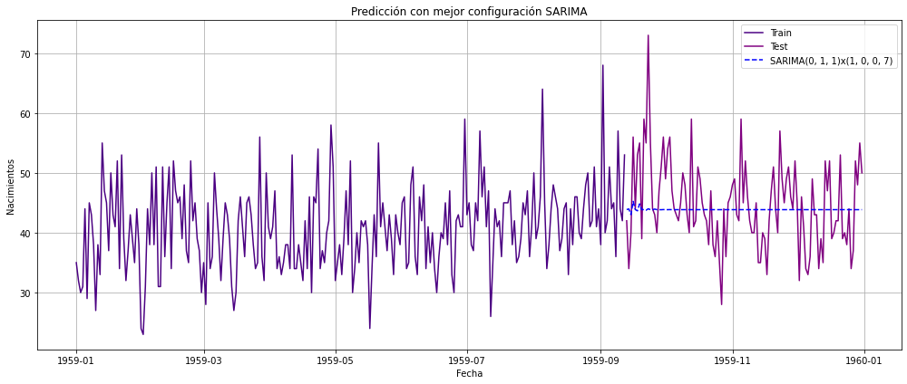

- La mejor configuración encontrada para el modelo SARIMA fue (0, 1, 1)x(1, 0, 0, 7), lo cual indica que el modelo utiliza una diferenciación no estacional, un promedio móvil simple y un componente autorregresivo estacional semanal. En la gráfica, se observa que el modelo genera pronósticos bastante estables para el conjunto de prueba, con una línea azul punteada que se mantiene cercana al promedio reciente de los datos, pero que no logra capturar la gran variabilidad ni los picos abruptos de la serie. Aunque el modelo es efectivo para estabilizar el comportamiento general, no es el más adecuado cuando se requiere precisión en series con alta variación diaria como esta. Aun así, su desempeño es razonable y puede ser útil para escenarios donde se busca destacar una predicción conservadora sobre una altamente reactiva.

> Ver análisis completo

#### **shampoo**

**SARIMA**

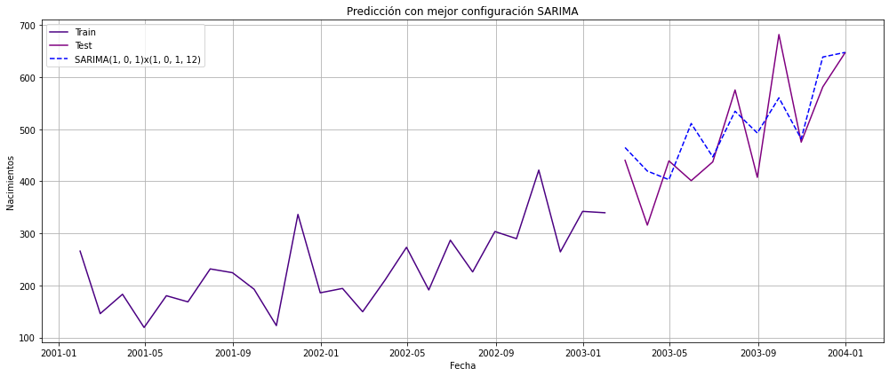

- Este gráfico muestra la predicción generada por el modelo **SARIMA** con la mejor configuración encontrada para la serie de ventas de shampoo, la cual incluye componentes autorregresivos y estacionales: `SARIMA(1, 0, 1)x(1, 0, 1, 12)`. En él se observan claramente tres segmentos: los datos de entrenamiento, los datos de prueba y la predicción (línea azul punteada).
- A diferencia de modelos más simples como el promedio móvil, SES o Holt, este modelo logra capturar con mayor precisión tanto la tendencia creciente como la estacionalidad presente en los datos. La línea de predicción no solo sigue la dirección ascendente de las ventas, sino que también refleja adecuadamente las oscilaciones recurrentes entre los meses, ajustándose de forma más realista al comportamiento observado en el periodo de prueba.
- Debido a su capacidad para incorporar patrones estacionales de largo plazo y dinámica temporal más compleja, el modelo SARIMA demuestra ser el más robusto entre los evaluados. Sus predicciones se acercan mucho a los valores reales, lo que sugiere que logra modelar de forma integral la estructura de la serie.

> Ver análisis completo

#### **monthly-car-sales**

**Prophet**

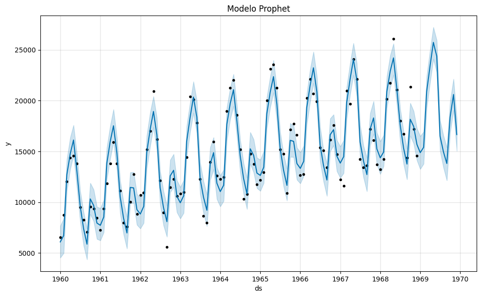

- El modelo Prophet fue configurado con su ajuste por defecto, utilizando diferenciación automática y componentes de tendencia y estacionalidad. Esto permitió al modelo adaptarse dinámicamente a los datos sin especificar manualmente parámetros como en otros modelos como SARIMA.
- La gráfica muestra las predicciones del modelo (línea azul sólida) alineadas con los datos históricos (puntos negros) desde 1960 hasta 1970. La banda sombreada en azul representa los intervalos de incertidumbre, reflejando una estimación adecuada de la variabilidad. El modelo captura con éxito la tendencia general ascendente y los patrones estacionales anuales, ajustándose bien a los picos y valles de las ventas.
- Prophet sobresale al manejar la alta variabilidad y los cambios abruptos en la serie de ventas de autos. A diferencia de modelos más rígidos, su capacidad para modelar tendencias y estacionalidades lo hace ideal para este dataset. Los pronósticos son precisos y confiables, siendo especialmente útil en escenarios donde se requiere prever tanto la tendencia a largo plazo como las fluctuaciones estacionales.

> Ver análisis completo

#### **monthly-mean-temp**

**Prophet**

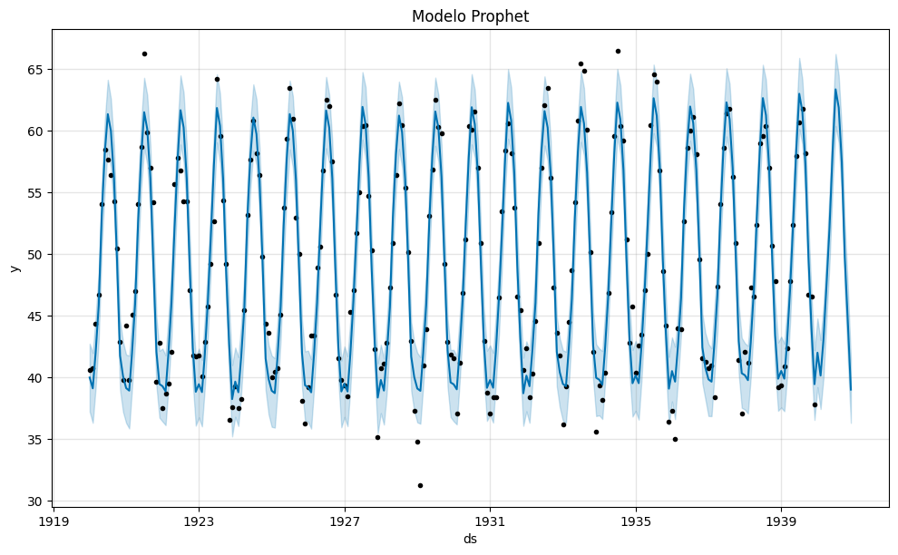

- El modelo Prophet fue configurado con su ajuste por defecto, empleando diferenciación automática y componentes de tendencia y estacionalidad, lo que le permitió adaptarse dinámicamente a los datos de temperaturas mensuales.
- La gráfica muestra las predicciones del modelo (línea azul sólida) alineadas con los datos históricos (puntos negros) de 1919 a 1939. La banda sombreada en azul representa los intervalos de incertidumbre, reflejando una estimación adecuada de la variabilidad. El modelo captura con éxito los patrones estacionales anuales y la tendencia general.
- Prophet logró un `MAE` de **1.700825** y un `RMSE` de **2.186984**, destacándose como el mejor modelo. Su capacidad para modelar tendencias y estacionalidades lo hace ideal para esta serie.
- Aún así, Holt-Winters obtuvo un `MAE` de **1.740151** y un `RMSE` de **2.230472**, mostrando un rendimiento cercano. Ambos modelos destacan por su diseño para series con tendencias y estacionalidades, como las temperaturas mensuales, gracias a sus enfoques aditivos que capturan patrones cíclicos de 12 meses.

> Ver análisis completo

### **Comparación de errores**

#### **daily-total-female-births**

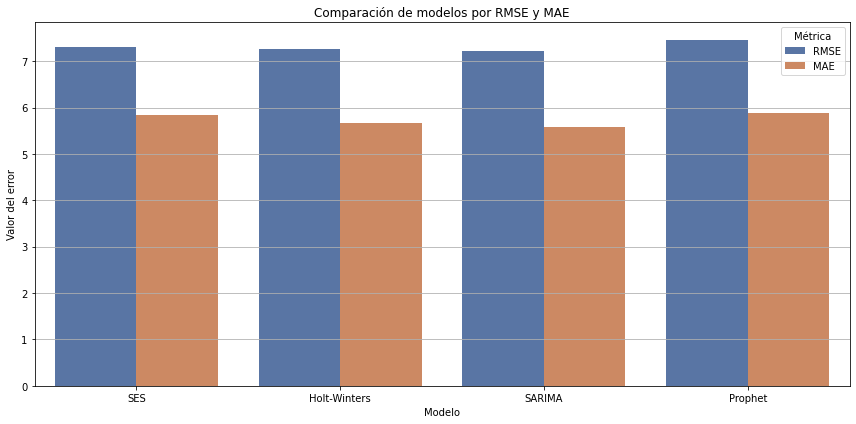

Este gráfico de barras muestra la comparación entre cuatro modelos de predicción, SES (Suavizamiento Exponencial Simple), Holt-Winters, SARIMA y Prophet, utilizando dos métricas comunes de error: `RMSE` (Root Mean Squared Error) y `MAE` (Mean Absolute Error). Estas métricas permiten evaluar el desempeño de cada modelo al predecir los nacimientos diarios. En general, mientras más bajos sean estos valores, mejor será la precisión del modelo.

A simple vista, el modelo **SARIMA** presenta los valores más bajos tanto para el `RMSE` como para el `MAE`, lo que indica que fue el más efectivo al capturar la dinámica del conjunto de datos. Aunque las diferencias con Holt-Winters no son extremadamente grandes, **SARIMA** logra una ligera mejora, especialmente en la métrica `MAE`, que es menos sensible a grandes errores puntuales.

Por otro lado, el modelo Prophet muestra los errores más altos en ambas métricas. A pesarde su capacidad para modelar tendencias y estacionalidades complejas, no logró adaptarse tan bien a las características particulares de esta serie temporal. De forma similar, el modelo SES también tuvo un desempeño inferior, lo cual era previsible dado que este método simple no considera estacionalidades ni tendencias explícitas.

Con base en las métricas presentadas, el modelo **SARIMA** es el más adecuado para este dataset, ya que logra un mejor equilibrio entre precisión y capacidad de generalización en la predicción.

> Ver análisis completo

#### **shampoo**

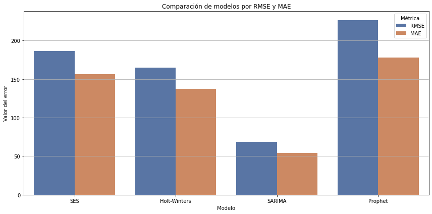

Este gráfico compara el desempeño de los cuatro modelos utilizados (SES, Holt-Winters, SARIMA y Prophet) en el dataset de ventas de shampoo, utilizando como métricas el `RMSE` (Root Mean Square Error) y el `MAE` (Mean Absolute Error).

Se observa que **SARIMA** es el modelo que obtiene el menor error, tanto en RMSE como en `MAE`, lo que indica que fue el más preciso en sus predicciones. Le sigue el modelo Holt-Winters, que también logra un desempeño aceptable, superando al modelo SES (Simple Exponential Smoothing), que presenta errores más altos.

Por otro lado, el modelo Prophet muestra el peor desempeño con los errores más elevados en ambas métricas. Esto sugiere que, a pesar de su flexibilidad, Prophet no logró ajustarse bien a los patrones específicos de este conjunto de datos, posiblemente por una sobreestimación de la tendencia en el periodo de prueba.

En conclusión, el modelo **SARIMA** resultó ser el más adecuado para este caso, logrando capturar tanto la tendencia como la estacionalidad del comportamiento de ventas con mayor precisión.

> Ver análisis completo

#### **monthly-car-sales**

- Comparación `RMSE` y `MAE`

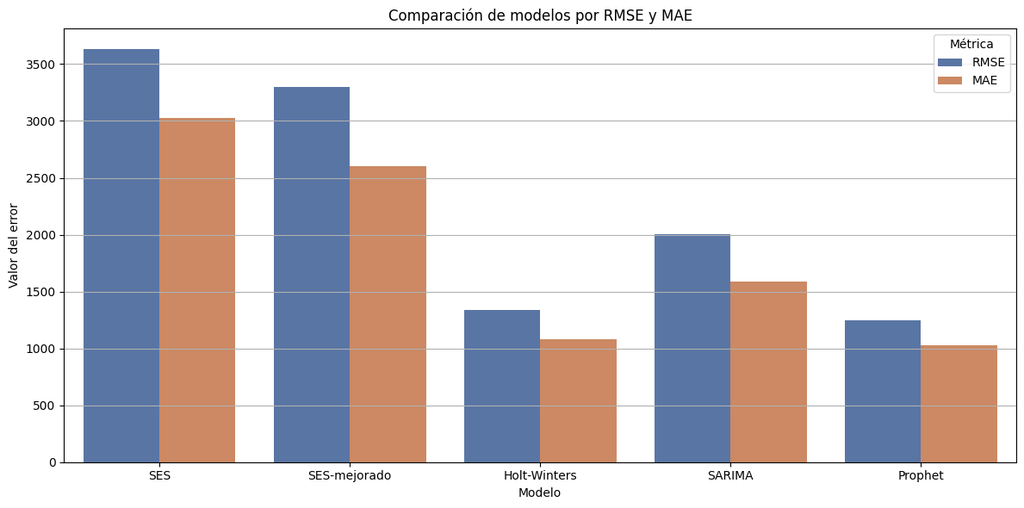

- Comparación de modelos por `MAPE`

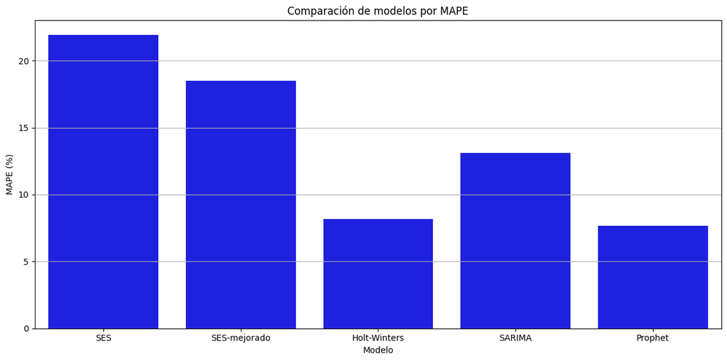

Al analizar el **error porcentual medio absoluto (MAPE)**, se observa que el modelo **Prophet** demuestra ser el más preciso, con un **MAPE** de `7.68%`, lo que indica que, en promedio, sus predicciones difieren menos del **8%** respecto a los valores reales. Le sigue muy de cerca el modelo **Holt-Winters**, con un **MAPE** de `8.15%`, lo cual también representa una excelente capacidad predictiva. Por su parte, **SARIMA** alcanzó un MAPE de `13.12%`, clasificándose como una predicción buena pero menos precisa en comparación con **Prophet** y **Holt-Winters**. Finalmente, en cuanto al **alisamiento exponencial simple (SES)**, el modelo original con `α = 0.6` obtuvo un MAPE de `21.93%`, indicando un ajuste limitado. No obstante, al ajustar el parámetro a `α = 1.0`, el SES mejoró su rendimiento a un MAPE de `18.49%`, reduciendo el error en comparación con su versión inicial. Aun así, ambos modelos SES se mantienen por debajo del rendimiento observado en los modelos que sí consideran estacionalidad y tendencia.

> Ver análisis completo

#### **monthly-mean-temp**

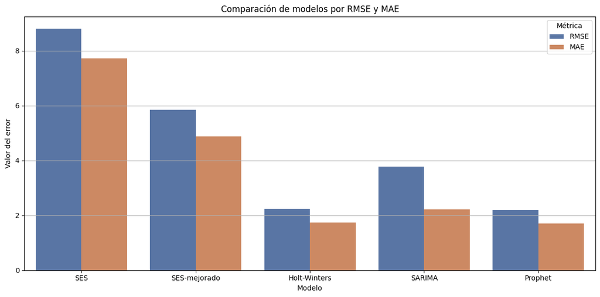

El modelo que mostró el mejor desempeño fue **Prophet**, al obtener el menor `MAE` y `RMSE`, lo que indica una mayor precisión general y menor sensibilidad a errores extremos. En segundo lugar se encuentra **Holt-Winters**, cuyos resultados fueron similares pero ligeramente inferiores, lo que sugiere que también logra capturar adecuadamente la tendencia y estacionalidad de la serie. El modelo **SARIMA**, incluso ajustando sus parámetros basados en los gráficos ACF y PACF tuvo un desempeño por debajo de *Prophet* y *Holt-Winters*. Esto puede deberse a que el modelo aún no captura completamente la dinámica de la serie, o a que la serie de tiempo se ajusta mejor a métodos no puramente estadísticos. Finalmente, el modelo **SES**, aunque mejoró significativamente tras ajustar el parámetro de suavizamiento α, sigue mostrando un desempeño inferior respecto a los demás modelos evaluados, debido a su incapacidad para capturar componentes como tendencia o estacionalidad.

> Ver análisis completo

### **Conclusiones**

Si bien el modelo **SARIMA** mostró un mejor desempeño en los datasets de ventas de shampoo y nacimientos diarios, probablemente debido a su capacidad de modelar series estacionarias y con estacionalidad regular de corta duración, el modelo **Prophet** fue el más preciso para los conjuntos de datos de temperatura y ventas mensuales de automóviles. Esto se debe a que Prophet está particularmente diseñado para series de tiempo con **tendencias a largo plazo, efectos estacionales anuales**, y **cambios estructurales suaves o irregulares**, lo cual encaja mejor con la naturaleza de estas series. Además, Prophet incluye por defecto manejo de días festivos y estacionalidades múltiples, lo cual lo hace más flexible frente a datos mensuales o con crecimiento no lineal.

Por otro lado, **SARIMA** tiende a funcionar muy bien con datos más **frecuentes (diarios o mensuales) que son estacionarios o se pueden hacer estacionarios con diferenciación**, y que siguen patrones más consistentes a lo largo del tiempo, como los nacimientos diarios o ventas repetitivas como en el caso del shampoo.

En trabajos futuros, se recomienda explorar la **optimización de hiperparámetros** y el uso de **validación cruzada temporal**, lo que permitiría obtener una comparación aún más robusta y ajustada a cada tipo de serie.

### **Referencias**

1. **12.2 Modelo Prophet** *| Predicción: Principios y práctica (edición tercera). (s. f.).* https://otexts.com/fppsp/profet.html
2. **Perú, D. S. R**. *(2022, 6 mayo). Modelos ARIMA, SARIMA y Método de Selección de Variables LASSO para Series Temporales (Parte 1). Data Science Research Perú.* https://datasciencepe.substack.com/p/modelos-arima-sarima-y-metodo-de
3. **Quick start.** *(2025, 30 mayo). Prophet.* https://facebook.github.io/prophet/docs/quick_start.html#python-api